# Using Machine Learning to Predict Students’ Adaptability Level in Online Education

Final Report: Group 2

Author

Sophia Maron Schaeffer & Valantina Zeremariam

Published

May 7, 2024

## Introduction and Data

Before the COVID-19 pandemic, Bangladesh had significantly improved in providing universal primary education and gender parity in equal access to education. However, a challenge faced was the quality of education, especially for marginalized communities. It did not help that the pandemic exacerbated challenges within the Bangladeshi education system. During the pandemic, educational institutions continued educational activities online. Bangladesh took a longer time to ensure that online education would be suitable for various educational levels. We are interested in exploring whether educational decision-makers designed online education optimally, based on surveys from students. It’s significant to understand the effectiveness of online education in fulfilling students’ needs and what next steps education institutions should take to ensure that students can reach their potential. An important aspect of academic learning is adaptability, and we were intrigued that the researchers used machine learning to measure the adaptability of the students surveyed.

#### Data Collection

The data set we used is from a research study conducted by the Daffodil International University[^1], one of the largest universities in Bangladesh. They collected this data via a survey they released from December 10, 2020, until February 5, 2021. Student information was gathered from various educational levels including universities, schools, and colleges. Each student who was surveyed represents one observation; a total of 1,205 observations are included in this dataset and none were omitted from the final dataset. We believe this is because the dataset may have already been used for other research studies done by the university, and thus it was cleaned before it was released publicly.

The original dataset had 14 variables - sex, age, education level, institution type, IT student, location, load shedding, financial condition, internet type, network type, class duration, self-LMS, device, and adaptivity level.

#### Data Wrangling

Our outcome variable is `adaptivity_level`. It is an ordinal categorical variable with three levels: low, moderate, and high. Based on our exploratory data analysis, we noticed there were very few High levels and thus we decided to merge this data with the Moderate level. In order to interpret the coefficients of the logistic regression models with more simplicity, we dichotomized the outcome variable into a factored variable with Low versus Not Low adaptivity levels.

## Research Questions and Hypotheses

Our two main research questions are:

1. Which predictor variables are the most important for predicting the adaptability level of students in Bangladesh?
2. Which model is better at predicting adaptivity levels: Logistic regression or Random forest?

**Hypothesis**

1. We believe that `age`, `sex`, and `financial_condition` will be the most important variables for predicting adaptivity level. More specifically, we hypothesized that older female students with higher socioeconomic status would have higher adaptive capacities.
2. We believe the random forest will be better at predicitng adaptivity levels because of its flexible nature.

## Methodology

#### Visualizations

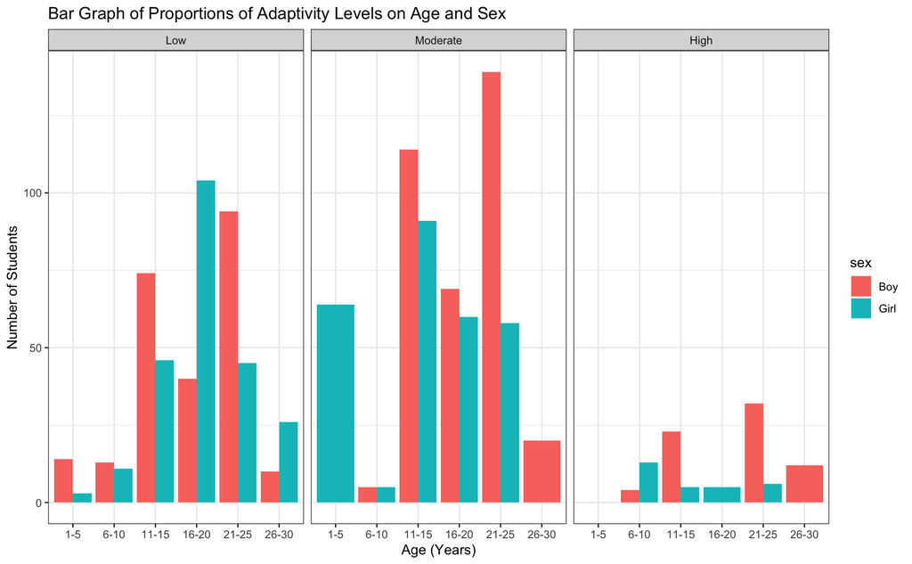

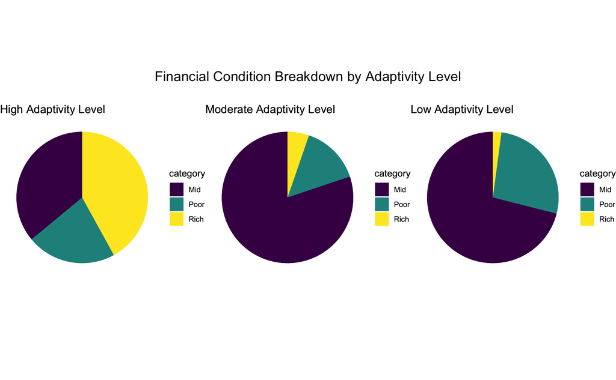

This graph shows the distribution of financial conditions across adaptivity levels of the observations. Keep in mind that in this data, the majority of respondents to the survey are middle class. Interestingly, there are very low proportions of rich respondents in the low and moderate adaptivity categories, but in the high adaptivity category, the rich financial condition is nearly half of the total (42%).

#### Rationale for Machine Learning Models

For this analysis, we used random forest classification and logistic regression as our predictive models on the dataset. Classification is an area of supervised machine learning that tries to predict which class or category some entity belongs to, based on predictor variables.

The rationale behind choosing a random forest is its ability to use multiple trees, thus lessening the variation compared to a single tree. The random forest is more complex, since each tree is trained on a random subset of the data. These individual predictions are then used to yield a more robust and accurate prediction. Additionally, random forests carve up feature space and they have many diverging variables, making a tree a potentially better option than a linear function because of its inherent flexibility.

Due to the nature of our outcome as a categorical variable, we decided to use a logistic regression for binary classification as well. This logistic regression model is trying to predict whether a student’s adaptivity level is low or not low, based on the following given factors of the student: `sex`, `age`, `education_level`, `institution_type`, `financial_condition`, `internet_type`, `network_type`, `class_duration`. We were more interested in estimating probabilities of our observations belonging to either category of adaptivity level since it is more valuable to have an estimate of probability that a student had a low adaptivity level based on characteristics of their environment and circumstances, than a discrete classification of low adaptivity level or not.

#### Methods of Analysis

In order to build predictive models using random forest and logistic regression, we set up a transformer, made a train-test validation split, and created and fit pipelines. The same split was used on each model to ensure the models were being trained and tested on the same unseen data. For the random forest, we analyzed variable importance and for logistic regression, we analyzed prediction probabilities. The accuracy of the random forest and logistic regression models were measured and compared with an ROC curve.

## Random Forest Classifier

The best parameters are {’estimator__max_features’: 2, ’estimator__n_estimators’: 300} with a best score of -0.134.

This means there are 300 trees in this Random Forest and the maximum number of features splitting at each node is two. The best score is low, indicating better predictive accuracy and fit to this dataset.

#### Variable Importance Plot

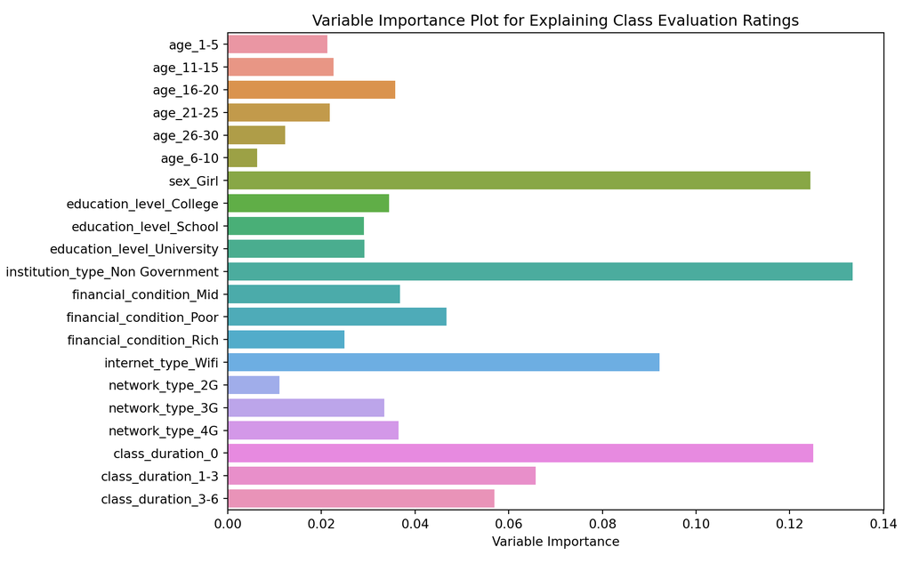

#### ROC Curve

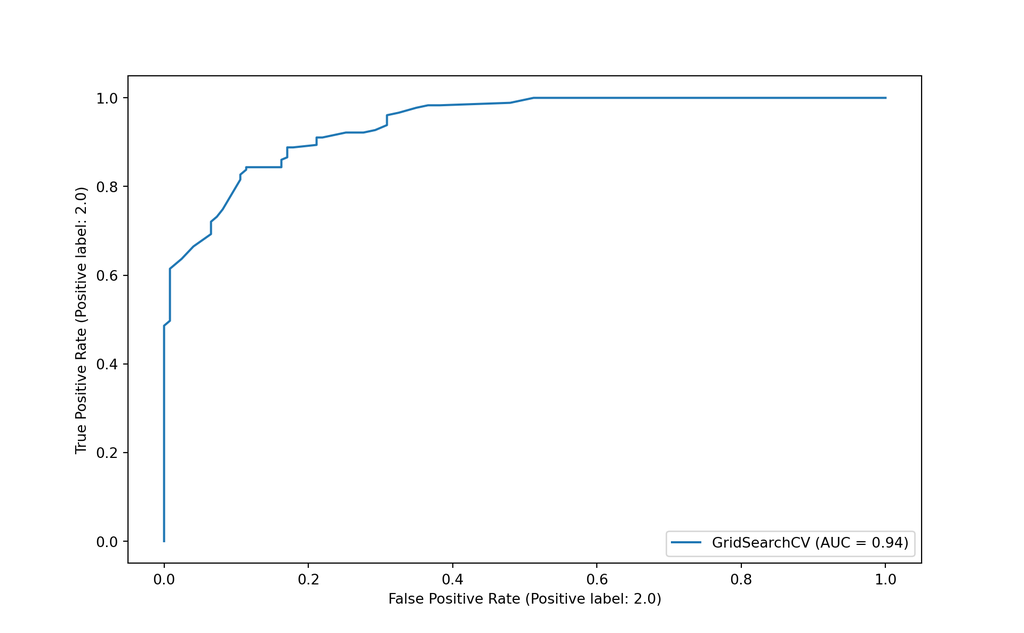

This plot shows validation-set ROC curve for the Random Forest model using certain predictors. The curve is very close to the top-left corner, with an AUC of 0.94 reported in the lower right corner, indicating great fit. Thus, the random forest shows a strong predictive ability of student adaptivity level.

## Logistic Regression Model

#### ROC Curve

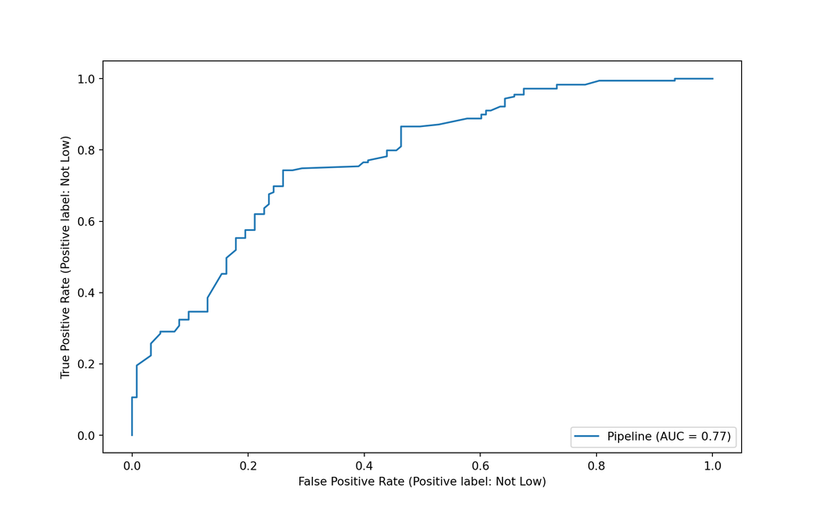

This plot shows validation-set ROC curve for the Logistic Regression model using certain predictors. The curve is pretty close to the top-left corner, with an AUC of 0.77 reported in the lower right corner, indicating decent fit. Thus, the logistic regression shows an adequate predictive ability of student adaptivity level.

The coefficients for each of the predictor variables were:

```
| Variables                       |   Coefficients |
|:--------------------------------|---------------:|
| sex_Girl                        |     -0.307112  |
| age_11-15                       |     -0.325258  |
| age_16-20                       |      0.163712  |
| age_21-25                       |      0.0981163 |
| age_26-30                       |      0.715128  |
| age_6-10                        |      0.0358694 |
| education_level_School          |      1.35396   |
| education_level_University      |      0.535182  |
| institution_type_Non Government |      1.00872   |
| financial_condition_Poor        |     -1.02665   |
| financial_condition_Rich        |      1.04425   |
| internet_type_Wifi              |     -0.567947  |
| network_type_3G                 |      1.49005   |
| network_type_4G                 |      2.28651   |
| class_duration_1-3              |      3.63173   |
| class_duration_3-6              |      4.49808   |
```

#### Improved Logistic Regression AUC Score

We decided to create interactions between each of the variables and refit the model on this, in hopes of it predicting better on the unseen data. We used the PolynomialFeatures transformer in our preprocessor.

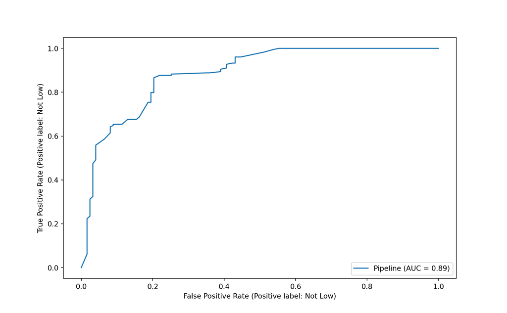

This plot shows validation-set ROC curve for the improved Logistic Regression model using certain predictors and bivariate interactions. The curve is closer to the top-left corner, with an AUC of 0.89 reported in the lower right corner, indicating good fit. Thus, the logistic regression with interaction terms shows a better predictive ability of student adaptivity level than without interactions.

There were 137 bivariate interaction terms. These coefficients have a greater range of values than those found in the initial logistic regression.

## Discussion

#### Conclusion

The variable importance plot suggests a strong association between the most important variables and adaptivity level. Based on the plot we fitted, `sex`, `institution_type`, `internet_type`, and `class_duration` were the best at predicting student adaptivity level. There are some reasons for why we believe certain variables had greater predictive abilities than others. Sex may influence adaptivity levels through gender-specific socialization patterns. Institution type and internet access may reflect varying levels of resources and support available to students, impacting their adaptability. Lastly, class duration could affect adaptivity by shaping students’ learning experiences and engagement levels over time.

#### Analysis Flaws

To have consistency in our models, we fit both models on the same training data evaluated both on the same test data, and assessed each of the models’ accuracies using an ROC curve. We removed certain variables to avoid overfitting. However, it is important to note that correctly predicting one outcome may mean we don’t correctly predict the other outcome. Hence, our high percentage of prediction accuracy for having a “Not Low” adaptivity level is not always the best method, since we could theoretically predict that all observations were “Not Low” and get a 100% accuracy. This issue could have been a cause of our logistic regression model having a lower AUC score.

Additionally, by creating 137 bivariate interactions in our improved logistic regression model, this made it very difficult to interpret each coefficient.

#### Ethical Concerns

This research yields insights into some determinants shaping students’ adaptability within their learning environment. It’s crucial to be cautious in creating broad conclusions and to recognize the ethical considerations involved. Nevertheless, these findings offer a pathway to address challenges encountered by students in Bangladesh, guiding the development of targeted interventions and support strategies. Some risks to this research are potential oversimplification of complex factors, inadvertent reinforcement of stereotypes, and unintentional marginalization of certain communities. Thus, there needs to be more research validating these findings, and it is imperative to ensure the responsible application of these findings in educational practices.

#### Future Improvements

In a future analysis, it would be interesting to create more interaction terms, by increasing the degrees of the existing variables. More polynomial degrees correspond to more parameters which could fit the data better and have a higher likelihood. More interactions do mean a higher risk of overfitting, though. Thus, the goal is to find a polynomial that fits the data the best, knowing that the correlation between predictors is not linear. While our AUC score was very high for our random forest, we believe this was influenced by how broad the categories were for adaptivity level. While an outcome with more levels would likely make it more difficult for the model to predict accurately, it would be a better representation of the true student adaptivity levels. Moreover, this dataset was specific to Bangladesh and it would be important to include more data from various countries and/or a more diverse survey group. This way we would be able to use new variables, such as race and ethnicity, that may also impact students’ adaptability levels.

## Footnotes

[^1]: Suzan, Md. Mahmudul & Samrin, Nishat & Biswas, Al Amin & Pramanik, Md. (2021). Students’ Adaptability Level Prediction in Online Education using Machine Learning Approaches. 1-7. 10.1109/ICCCNT51525.2021.9579741.